# Reproducible Research: Peer Assessment 1

```r
  library(ggplot2)
```

## Loading and preprocessing the data

1. Download and unzip data

```r
  if(!file.exists('data')) dir.create('data')
  fileUrl <- 'http://d396qusza40orc.cloudfront.net/repdata%2Fdata%2Factivity.zip'
  download.file(fileUrl, destfile = './data/activity_data.zip')
  unzip('./data/activity_data.zip', exdir = './data')
```

2. Read data

```r
  activityData <- read.csv('./data/activity.csv')
  summary(activityData)
```

```
##      steps                date          interval
##  Min.   :  0.00   2012-10-01:  288   Min.   :   0.0
##  1st Qu.:  0.00   2012-10-02:  288   1st Qu.: 588.8
##  Median :  0.00   2012-10-03:  288   Median :1177.5
##  Mean   : 37.38   2012-10-04:  288   Mean   :1177.5
##  3rd Qu.: 12.00   2012-10-05:  288   3rd Qu.:1766.2
##  Max.   :806.00   2012-10-06:  288   Max.   :2355.0
##  NA's   :2304     (Other)   :15840
```

## What is mean total number of steps taken per day?

1. Calculate the total number of steps taken per day

```r
  stepsPerDay <- aggregate(steps ~ date, activityData, sum, na.rm=TRUE)
```

2. Make a histogram of the total number of steps taken each day

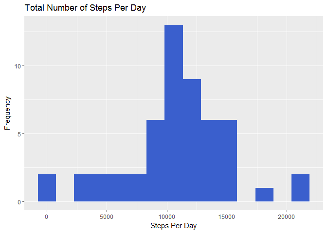

```r
  ggplot(stepsPerDay, aes(x = steps)) +
  geom_histogram(fill = "royalblue3", bins = 15)+
  ggtitle("Total Number of Steps Per Day") + xlab("Steps Per Day") + ylab("Frequency")
```

3. Calculate and report the mean and median of the total number of steps taken per day

```r
  mean(stepsPerDay$steps)
```

```
## [1] 10766.19
```

```r
  median(stepsPerDay$steps)
```

```
## [1] 10765
```

## What is the average daily activity pattern?

1. Make a time series plot (i.e. type = “l”) of the 5-minute interval (x-axis) and the average number of steps taken, averaged across all days (y-axis)

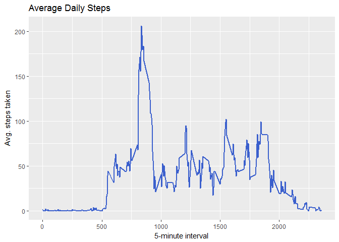

```r
  stepsPerInterval<-aggregate(steps~interval, activityData, mean, na.rm=TRUE)
  ggplot(stepsPerInterval, aes(x = interval , y = steps)) + geom_line(color="royalblue3", size=1) +
  labs(title = "Average Daily Steps", x = "5-minute interval", y = "Avg. steps taken")
```

2. Which 5-minute interval, on average across all the days in the dataset, contains the maximum number of steps?

```r
  maxSteps <- stepsPerInterval[which.max(stepsPerInterval$steps),1]
  print(maxSteps)
```

```
## [1] 835
```

## Imputing missing values

1. Calculate and report the total number of missing values in the dataset (i.e. the total number of rows with NAs)

```r
  missingValues <- sum(is.na(activityData$steps))
  print(missingValues)
```

```
## [1] 2304
```

2. Devise a strategy for filling in all of the missing values in the dataset. The strategy does not need to be sophisticated. For example, you could use the mean/median for that day, or the mean for that 5-minute interval, etc.

```r
  #fill in all the missing values in the dataset with the mean per interval
  getMeanPerInterval<-function(interval){
    stepsPerInterval[stepsPerInterval$interval==interval,]$steps
  }
```

3. Create a new dataset that is equal to the original dataset but with the missing data filled in.

```r
  dataWMissing <- activityData
  for(i in 1:nrow(dataWMissing)){
      if(is.na(dataWMissing[i,]$steps)){
        dataWMissing[i,]$steps <- getMeanPerInterval(dataWMissing[i,]$interval)
      }
  }
```

4. Make a histogram of the total number of steps taken each day and Calculate and report the mean and median total number of steps taken per day. Do these values differ from the estimates from the first part of the assignment? What is the impact of imputing missing data on the estimates of the total daily number of steps?

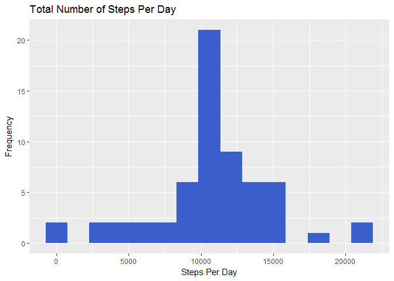

```r
  newStepsPerDay <- aggregate(steps ~ date, dataWMissing, sum)

  ggplot(newStepsPerDay, aes(x = steps)) +
  geom_histogram(fill = "royalblue3", bins = 15) + ggtitle("Total Number of Steps Per Day") +
  xlab("Steps Per Day") + ylab("Frequency")
```

```r
  mean(newStepsPerDay$steps)
```

```
## [1] 10766.19
```

```r
  median(newStepsPerDay$steps)
```

```
## [1] 10766.19
```

- Comparing with the result prevoiously calculated, the mean doesn’t change and the median is very close to the original value. The variation taking into account the missing values is not significant.

## Are there differences in activity patterns between weekdays and weekends?

1. Create a new factor variable in the dataset with two levels - “weekday” and “weekend” indicating whether a given date is a weekday or weekend day.

```r
  weekday.or.weekend <- function(date) {
      day <- weekdays(date)
      if (day %in% c("Monday", "Tuesday", "Wednesday", "Thursday", "Friday"))
          return("weekday") else if (day %in% c("Saturday", "Sunday"))
          return("weekend") else stop("invalid date")
  }
  dataWMissing$date <- as.Date(dataWMissing$date)
  dataWMissing$day <- sapply(dataWMissing$date, FUN = weekday.or.weekend)
```

2. Make a panel plot containing a time series plot (i.e. type = “l”) of the 5-minute interval (x-axis) and the average number of steps taken, averaged across all weekday days or weekend days (y-axis). See the README file in the GitHub repository to see an example of what this plot should look like using simulated data.

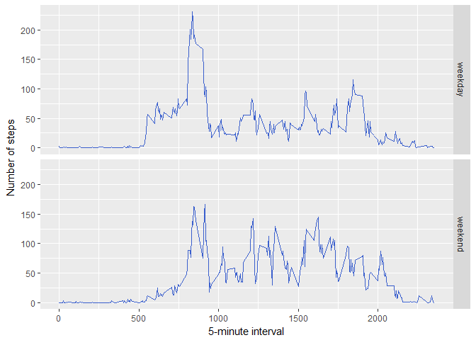

```r
  averages <- aggregate(steps ~ interval + day, dataWMissing, mean)
  ggplot(averages, aes(interval, steps)) + geom_line(color="royalblue3") + facet_grid(day ~ .) +
    xlab("5-minute interval") + ylab("Number of steps")
```